# Population Aging in the Netherlands

BoatGoBinter

2025-11-29

# Introduction

Population aging has become one of the most significant demographic shifts of the 21st century. Many in Europe, including the Netherlands, are experiencing rising proportions of elderly due to declining birth rates and the increasing life expectancy. As someone who has studied and lived in Korea, a country that has the worst aging crisis in the world, this topic holds personal relevance and importance. Understanding how aging varies across regions can help us identify where we need to pay close attention to issues that are creating from an aging population, like social, economic, and healthcare challenges. This study will compare province sin the Netherlands and analyze which regions are aging the most, using recent population and age-distribution data.

# Background

The theory behind population aging is when the amount of elderly increases compared to younger populations. This is phenomenon is occurring globally, specifically in Western European and East Asian countries, and it will continue to increase in the future decades (UN DESA, 2022). South Korea is a country that is at the forefront of this problem and it is illustrating the problems that can arise from it like social and economic pressures (OECD 2023). The Netherlands, albeit at a much lower decreasing rate, is also encountering a steady rise in an aging population. Looking at the provincial demographic statistics of the Netherlands can help us identify the key regions that may be encountering a high rate of aging populations. So, using spatial populations datasets, will allow us to take on geographic perspective on demographic change and making it possible to identify spatial patterns and assess possible uneven distributions of aging across the Netherlands.

United Nations Department of Economic and Social Affairs (UN DESA). *World Population Prospects 2022*. https://population.un.org/wpp/

OECD (2023). *Aging and Demographic Change in Korea*. https://www.oecd.org/korea/

# Data and Methods

### Load Libraries:

```r
library(tidyverse)
library(sf)
library(tmap)
library(readr)
```

### Importing the Data

```r
pop_csv <- "https://drive.google.com/uc?export=download&id=18K6cuNFoosLUOn5nVbWw-ubpXZRxtlCJ"
prov_geojson <- "https://drive.google.com/uc?export=download&id=1UMOJRm82Y8Xrbc1BQsHoxCNVpbx9Xe1Q"

p_pop <- read_csv(pop_csv)
p_map <- st_read(prov_geojson)
```

#### This data comes from two different sources. The CSV with the population data comes from https://allecijfers.nl. AlleCijfers pulls from a variety of official open-data sources. This data is from the CBS – Centraal Bureau voor de Statistiek. The GeoJson comes from Basisregistratie Kadaster (Kadaster.nl). Kadaster is the official Dutch authority responsible for: national cadastral records property boundaries administrative geography official provincial and municipal boundaries.

Here is what the variables from both datasets represent:

Dutch Provincial Age Population Demographics.csv variables:

Provincienaam – The name of the Dutch province.  
% 0 tot 15 jaar – Percentage of the population aged 0–15.  
% 15 tot 25 jaar – Percentage of the population aged 15–25.  
% 25 tot 45 jaar – Percentage of the population aged 25–45.  
% 45 tot 65 jaar – Percentage of the population aged 45–65.  
% 65 jaar of ouder – Percentage of the population aged 65 and older.

Netherlands Provincial Maps.geojson variables:

geo_point_2d – A latitude–longitude point for the centroid of the province.  
year – The reference year of the geographic dataset.  
prov_code – The internal province identifier used by Opendatasoft.  
prov_name – The official name of the province.  
prov_area_code – The administrative area code assigned to the province.  
prov_type – The administrative unit type (province).  
prov_cbs_code – The CBS (Statistics Netherlands) official province code.

### Cleaning the data

This just cleans and standardizes the population dataset by renaming the columns and converting all percentage values into numeric format so they can be analyzed and mapped correctly.

```r
p_pop_clean <- p_pop |>
  rename(
    provincienaam = Provincienaam,
    pct_0_15 = `% 0 tot 15 jaar`,
    pct_15_25 = `% 15 tot 25 jaar`,
    pct_25_45 = `% 25 tot 45 jaar`,
    pct_45_65 = `% 45 tot 65 jaar`,
    pct_65_plus = `% 65 jaar of ouder`
  ) |>
  mutate(
    across(
      c(pct_0_15, pct_15_25, pct_25_45, pct_45_65, pct_65_plus),
      ~ parse_number(.x)
    )
  )
```

Here we need to fix the provincial name variables and join

```r
p_pop_clean <- p_pop_clean |>
  mutate(
    prov_join = as.character(provincienaam),
    prov_join = ifelse(prov_join == "Fryslân (Friesland)", "Friesland", prov_join)
  )

# join key for friesland
p_map_clean <- p_map |>
  mutate(
    prov_join = as.character(prov_name),
    prov_join = ifelse(prov_join == "Fryslân", "Friesland", prov_join)
  )

# join and reproject
nl_map <- p_map_clean |>
  left_join(p_pop_clean, by = "prov_join") |>
  st_transform(28992)
```

st_transform(28992) converts the map’s coordinates into the Dutch national projection

#### Descriptive Statistics:

```r
#vector creation
age_vars <- c("pct_0_15", "pct_15_25", "pct_25_45", "pct_45_65", "pct_65_plus")

summary(p_pop_clean[age_vars])
```

```
##     pct_0_15       pct_15_25       pct_25_45       pct_45_65
##  Min.   :13.00   Min.   :11.00   Min.   :21.00   Min.   :25.00
##  1st Qu.:14.00   1st Qu.:11.75   1st Qu.:23.00   1st Qu.:26.00
##  Median :15.00   Median :12.00   Median :24.50   Median :26.50
##  Mean   :14.92   Mean   :12.25   Mean   :24.75   Mean   :26.42
##  3rd Qu.:15.25   3rd Qu.:13.00   3rd Qu.:27.00   3rd Qu.:27.00
##  Max.   :18.00   Max.   :15.00   Max.   :28.00   Max.   :28.00
##   pct_65_plus
##  Min.   :16.00
##  1st Qu.:19.00
##  Median :21.50
##  Mean   :21.42
##  3rd Qu.:23.50
##  Max.   :26.00
```

From these summary statistics, we can conclude that the Netherlands has an aging provincial population overall. The mean share of elderly residents (65+) across provinces is 21.4%, with some provinces reaching as high as 26%. This is about 1 in 5 people in the average Dutch province is elderly.

```r
p_pop_clean |>
summarise(
mean_0_15 = mean(pct_0_15),
sd_0_15 = sd(pct_0_15),
mean_15_25 = mean(pct_15_25),
sd_15_25 = sd(pct_15_25),
mean_25_45 = mean(pct_25_45),
sd_25_45 = sd(pct_25_45),
mean_45_65 = mean(pct_45_65),
sd_45_65 = sd(pct_45_65),
mean_65plus = mean(pct_65_plus),
sd_65plus = sd(pct_65_plus)
)
```

```
## # A tibble: 1 × 10
##   mean_0_15 sd_0_15 mean_15_25 sd_15_25 mean_25_45 sd_25_45 mean_45_65 sd_45_65
##       <dbl>   <dbl>      <dbl>    <dbl>      <dbl>    <dbl>      <dbl>    <dbl>
## 1      14.9    1.38       12.2     1.14       24.8     2.34       26.4    0.900
## # ℹ 2 more variables: mean_65plus <dbl>, sd_65plus <dbl>
```

#### Graphing

```r
#long format
p_long <- p_pop_clean |>
  pivot_longer(
    cols = all_of(age_vars),
    names_to = "variable",
    values_to = "percent"
  )
```

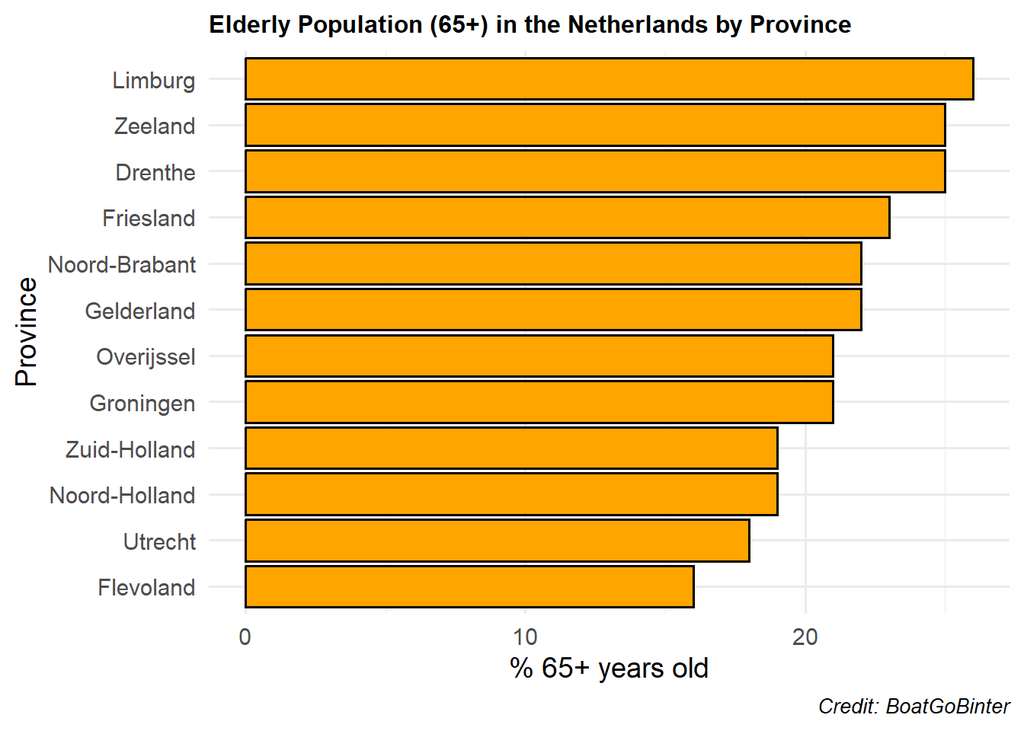

```r
pdist_barplot <-
  ggplot(p_pop_clean, aes(x = reorder(provincienaam, pct_65_plus),
                      y = pct_65_plus)) +
  geom_col(fill = "orange", color = "black") +
  coord_flip() +
  labs(
    title = "Elderly Population (65+) in the Netherlands by Province",
    x = "Province",
    y = "% 65+ years old",
    caption = "Credit: BoatGoBinter"
  ) +
  theme_minimal(base_size = 14) +
  theme(
    plot.title = element_text(size = 12, face = "bold"),
    plot.caption = element_text(hjust = 1, size = 10, face = "italic")
    )
pdist_barplot
```

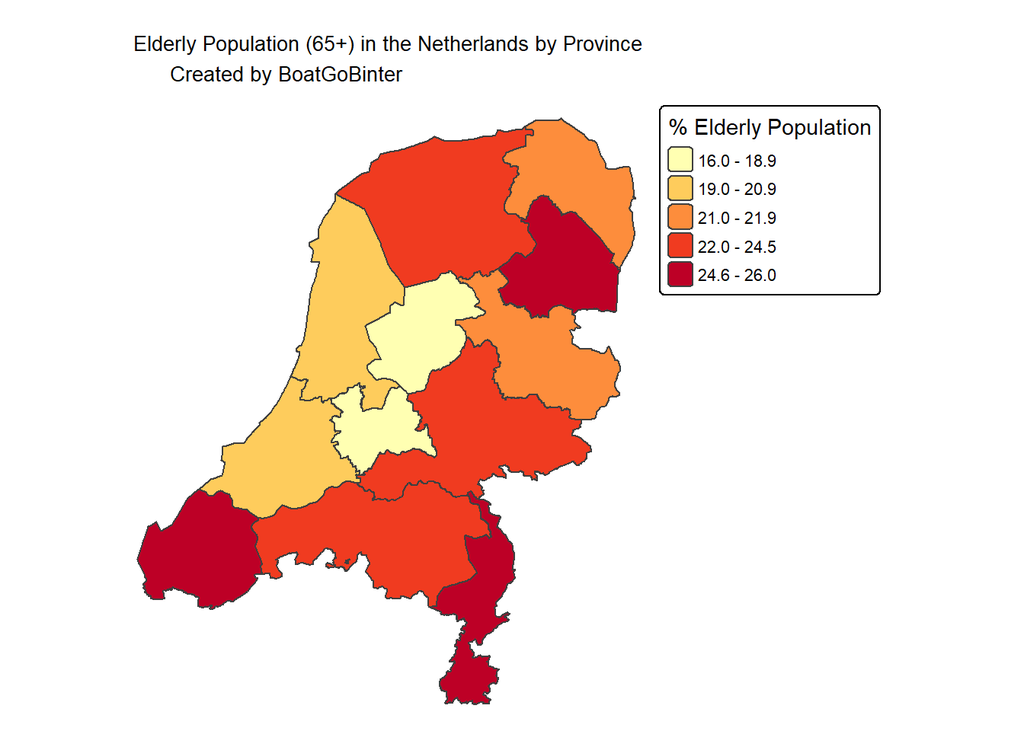

```r
tmap_options(component.autoscale = FALSE)
eldpop_map <-
  tm_shape(nl_map) +
    tm_polygons(
      fill = "pct_65_plus",
      fill.scale = tm_scale_intervals(
        style = "quantile",
        n = 5,
        values = "brewer.yl_or_rd"   # YlOrRd
      ),
      fill.legend = tm_legend(title = "% Elderly Population")
    ) +
    tm_title(
      "Elderly Population (65+) in the Netherlands by Province
      Created by BoatGoBinter",
      size = 0.9,
    ) +
    tm_layout(
      legend.outside = TRUE,
      frame = FALSE
    )
eldpop_map
```

## Linear Regression

This data is taken from Eurostat (https://ec.europa.eu/eurostat/databrowser/view/tps00028__custom_19123311/default/table)

```r
dutchpop_overtime <- "https://drive.google.com/uc?export=download&id=148JuGrVSeZo3CJoNAratM9wh1M9TyI2P"
popovertime <- read_csv(dutchpop_overtime)
popovertime <- popovertime |>
  rename(
    year = TIME_PERIOD,
    pct_65_plus = OBS_VALUE
  ) |>
  mutate(
    year = as.numeric(year),
    pct_65_plus = as.numeric(pct_65_plus)
  )

model <- lm(pct_65_plus ~ year, data = popovertime)

summary(model)
```

```
##
## Call:
## lm(formula = pct_65_plus ~ year, data = popovertime)
##
## Residuals:
##      Min       1Q   Median       3Q      Max
## -0.29359 -0.13109  0.07179  0.11987  0.17180
##
## Coefficients:
##               Estimate Std. Error t value Pr(>|t|)
## (Intercept) -641.00256   27.50452  -23.30 4.79e-10 ***
## year           0.32692    0.01363   23.99 3.60e-10 ***
## ---
## Signif. codes:  0 '***' 0.001 '**' 0.01 '*' 0.05 '.' 0.1 ' ' 1
##
## Residual standard error: 0.1629 on 10 degrees of freedom
## Multiple R-squared:  0.9829, Adjusted R-squared:  0.9812
## F-statistic: 575.6 on 1 and 10 DF,  p-value: 3.598e-10
```

### Analysis:

From this model we can see that the percentage of elderly residents in the Netherlands has increased significantly in the last decade. Our p-value is 3.598e-10, showing that this trend is not random and is systematic and progressive. Every year contributes to a measurable increase of percentage elderly in the Netherlands.

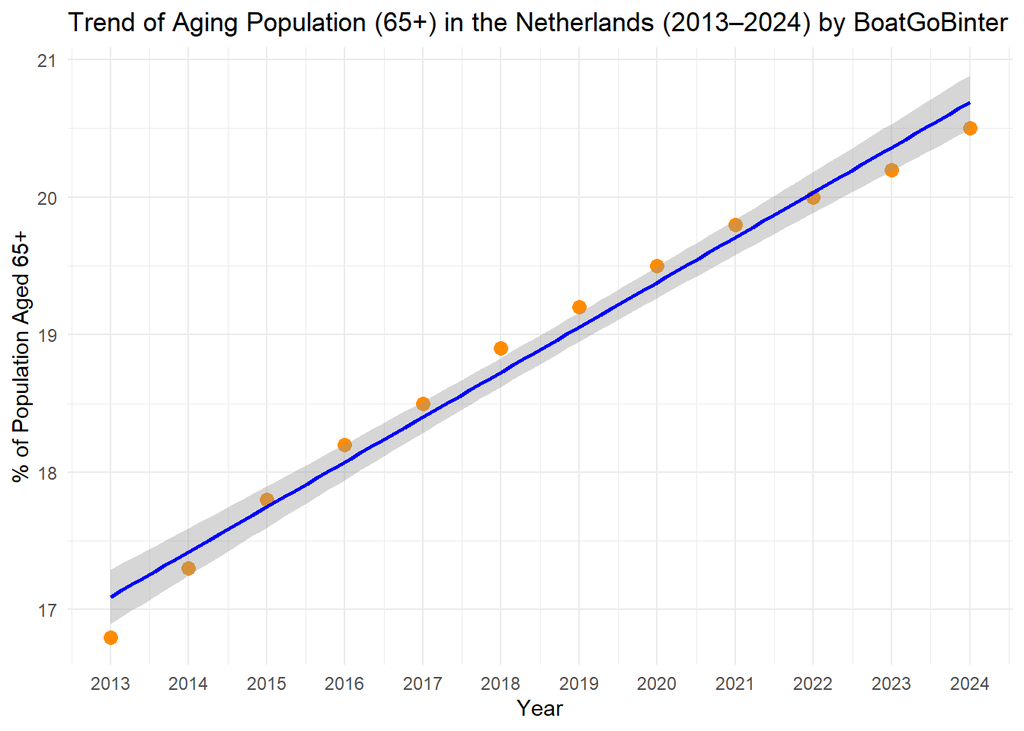

```r
aging_pop_trend <-
ggplot(popovertime, aes(x = year, y = pct_65_plus)) +
  geom_point(size = 3, color = "darkorange") +
  geom_smooth(method = "lm", se = TRUE, color = "blue") +
   scale_x_continuous(breaks = unique(popovertime$year))+
  labs(
    title = "Trend of Aging Population (65+) in the Netherlands (2013–2024) by BoatGoBinter",
    x = "Year",
    y = "% of Population Aged 65+"
  ) +
  theme_minimal()
aging_pop_trend
```

# Conclusions

#### What did I find?

From the shading map and ranked bar chart, I found clear differences in the elderly population across the Dutch provinces. Limburg, Zeeland, and Drenthe have much higher elderly populations (24-26%).

On the other hand, Flevoland, Utrecht, and Noord-Holland have significantly lower elderly populations (16-19%). Possible reasons for this is Utrecht being a province with a city containing lots of college students, Flevoland is a newer province and old people did not grow up there, and Noord-Holland has Amsterdam which is full of students and young working professionals, which keeps the median age low.

This shows that population aging is not evenly distributed across the Netherlands.

#### How did it differ from what I expected?

The provinces with the highest didn’t differ much; however, the percentages of elderly did. Over 25% is a lot of elderly people in specific regions. Moreover, according to EUROSTAT, the % 65+ population in the Netherlands in 2010 was 15.3% (https://tradingeconomics.com/netherlands/proportion-of-population-aged-65-over-eurostat-data.html). Now, if we take a look:

```r
p_pop_clean <- p_pop_clean |>
  mutate(
    pct_65_plus = as.numeric(pct_65_plus),
    pct_65_plus_dec = pct_65_plus / 100
  )

avg_65_dec <- mean(p_pop_clean$pct_65_plus_dec)
avg_65_dec
```

```
## [1] 0.2141667
```

## Were the results significant?

Yes, the results are very significant because the differences in elderly population percentages across provinces are large, consistent, and meaningful enough to indicate clear regional demographic patterns.

## What do the results imply/suggest?

The results suggest that aging population is a variable the Dutch government should take seriously, as aging populations are important to be aware of as they can put stress on healthcare systems, shrink the labor force, and increase dependency. Thus, this is a demographic challenge that requires long-term planning from the Dutch government.

## What might you do differently next time?

I think I would look at potential factors that may cause an aging population that is not covered widely in study. Other than this, I am quite happy with my project.